# Seedling density across a gradient of fire severity

Anna Talucci

20 July 2019

# Overview

For short interval beetle+fire disturbances we are interested if time since beetle attack impacts the aerial seedbank and subsequent regeneration after fire. Seedling count data was acquired over various sized plots; in order to account for this we analyzed out data as a negative bionomial and accounted for the effort of the seedling count collection. Effort refers to the log of the area in which seedlings were counted in.

The goal of this analysis is twofold. First, to assess seedling density as a function of plots burning or not burning. Second, to assess seedling density as a function of the type of burning conditions - unburned, surface, severe surface, and crown.

Seedling density was gathered as a variety of scales from 1 square meter to 100 square meters. Seedlings is being used broadly to include saplings (larger, older, more developed trees) in unburned plots. Due to the variability in plot size for data collection, we will account for this in our statistical models. Plot size is the effort and is accounted for in the statistical model with an offset for area.

# Packages

# Data

## Burn plot data

```r
fire = read.csv("../data/2018-09-20_ch2-burnedplots-wcodes-edit43.csv", header = TRUE, sep = ",", strip.white = TRUE)
head(fire)
```

|  | plot | Plot_ID | plot.mpb | stems | bom | fire | live | upf | no.canopy | yes.canopy | no.seed | yes.seed | tot.stem | cone.ct | seed.density | disturbance | fire.type | burncon |
| --- | --- | --- | --- | --- | --- | --- | --- | --- | --- | --- | --- | --- | --- | --- | --- | --- | --- | --- |
| 1 | 1 | CEC0629M1 | LM1 | 7 | 0 | 7 | 0 | 0 | 0 | 7 | 0 | 7 | 7 | 282 | 75 | beetle+fire | sev.surf | moderate |
| 2 | 2 | CEC0630H1 | LM2 | 7 | 0 | 7 | 0 | 0 | 0 | 7 | 0 | 7 | 7 | 1150 | 1700 | beetle+fire | sev.surf | moderate |
| 3 | 3 | CEC0701L1 | LL3 | 42 | 17 | 21 | 3 | 1 | 4 | 38 | 28 | 14 | 42 | 3665 | 375 | beetle+fire | surface | moderate |
| 4 | 4 | CEC0702M1 | HM4 | 12 | 12 | 0 | 0 | 0 | 0 | 12 | 6 | 6 | 12 | 1286 | 150 | beetle+fire | sev.surf | moderate |
| 5 | 5 | CEC0702H1 | LH5 | 24 | 0 | 9 | 0 | 15 | 15 | 9 | 15 | 9 | 24 | 1585 | 375 | beetle+fire | crown | moderate |
| 6 | 6 | CEC0703M1 | LL6 | 20 | 16 | 4 | 0 | 0 | 10 | 10 | 15 | 5 | 20 | 680 | 2 | beetle+fire | surface | moderate |

## Burn plot data: Seedling Effort (area collected)

```r
fire.seedeffort = read.csv("../data/chapter2_analysis34_seedlingeffort_11december2017.csv", header = TRUE, sep = ",", strip.white = TRUE)
head(fire.seedeffort)
```

|  | plot | seedling.ct | seedling.area |
| --- | --- | --- | --- |
| 1 | 1 | 3 | 4 |
| 2 | 2 | 68 | 4 |
| 3 | 3 | 15 | 4 |
| 4 | 4 | 6 | 4 |
| 5 | 5 | 15 | 4 |
| 6 | 6 | 0 | 4 |

```r
fire.seedeffort
```

| plot | seedling.ct | seedling.area |
| --- | --- | --- |
| 1 | 3 | 4 |
| 2 | 68 | 4 |
| 3 | 15 | 4 |
| 4 | 6 | 4 |
| 5 | 15 | 4 |
| 6 | 0 | 4 |
| 7 | 4 | 4 |
| 8 | 6 | 4 |
| 9 | 6 | 4 |
| 10 | 5 | 4 |

[output cut: 53 more lines]

Here we will combine our effort data with our burn plot data

```r
burned3 = merge(fire, fire.seedeffort, by = c("plot"))
head(burned3)
```

|  | plot | Plot_ID | plot.mpb | stems | bom | fire | live | upf | no.canopy | yes.canopy | no.seed | yes.seed | tot.stem | cone.ct | seed.density | disturbance | fire.type | burncon | seedling.ct | seedling.area |
| --- | --- | --- | --- | --- | --- | --- | --- | --- | --- | --- | --- | --- | --- | --- | --- | --- | --- | --- | --- | --- |
| 1 | 1 | CEC0629M1 | LM1 | 7 | 0 | 7 | 0 | 0 | 0 | 7 | 0 | 7 | 7 | 282 | 75 | beetle+fire | sev.surf | moderate | 3 | 4 |
| 2 | 2 | CEC0630H1 | LM2 | 7 | 0 | 7 | 0 | 0 | 0 | 7 | 0 | 7 | 7 | 1150 | 1700 | beetle+fire | sev.surf | moderate | 68 | 4 |
| 3 | 3 | CEC0701L1 | LL3 | 42 | 17 | 21 | 3 | 1 | 4 | 38 | 28 | 14 | 42 | 3665 | 375 | beetle+fire | surface | moderate | 15 | 4 |
| 4 | 4 | CEC0702M1 | HM4 | 12 | 12 | 0 | 0 | 0 | 0 | 12 | 6 | 6 | 12 | 1286 | 150 | beetle+fire | sev.surf | moderate | 6 | 4 |
| 5 | 5 | CEC0702H1 | LH5 | 24 | 0 | 9 | 0 | 15 | 15 | 9 | 15 | 9 | 24 | 1585 | 375 | beetle+fire | crown | moderate | 15 | 4 |
| 6 | 6 | CEC0703M1 | LL6 | 20 | 16 | 4 | 0 | 0 | 10 | 10 | 15 | 5 | 20 | 680 | 2 | beetle+fire | surface | moderate | 0 | 4 |

```r
burned3 = mutate(burned3, prop.bom = bom/stems)
head(burned3)
```

|  | plot | Plot_ID | plot.mpb | stems | bom | fire | live | upf | no.canopy | yes.canopy | no.seed | yes.seed | tot.stem | cone.ct | seed.density | disturbance | fire.type | burncon | seedling.ct | seedling.area | prop.bom |
| --- | --- | --- | --- | --- | --- | --- | --- | --- | --- | --- | --- | --- | --- | --- | --- | --- | --- | --- | --- | --- | --- |
| 1 | 1 | CEC0629M1 | LM1 | 7 | 0 | 7 | 0 | 0 | 0 | 7 | 0 | 7 | 7 | 282 | 75 | beetle+fire | sev.surf | moderate | 3 | 4 | 0.0000000 |
| 2 | 2 | CEC0630H1 | LM2 | 7 | 0 | 7 | 0 | 0 | 0 | 7 | 0 | 7 | 7 | 1150 | 1700 | beetle+fire | sev.surf | moderate | 68 | 4 | 0.0000000 |
| 3 | 3 | CEC0701L1 | LL3 | 42 | 17 | 21 | 3 | 1 | 4 | 38 | 28 | 14 | 42 | 3665 | 375 | beetle+fire | surface | moderate | 15 | 4 | 0.4047619 |
| 4 | 4 | CEC0702M1 | HM4 | 12 | 12 | 0 | 0 | 0 | 0 | 12 | 6 | 6 | 12 | 1286 | 150 | beetle+fire | sev.surf | moderate | 6 | 4 | 1.0000000 |
| 5 | 5 | CEC0702H1 | LH5 | 24 | 0 | 9 | 0 | 15 | 15 | 9 | 15 | 9 | 24 | 1585 | 375 | beetle+fire | crown | moderate | 15 | 4 | 0.0000000 |
| 6 | 6 | CEC0703M1 | LL6 | 20 | 16 | 4 | 0 | 0 | 10 | 10 | 15 | 5 | 20 | 680 | 2 | beetle+fire | surface | moderate | 0 | 4 | 0.8000000 |

Select plot, fire.type, seedling.ct, seedling area

```r
( burnt.plot = burned3 %>%
    dplyr::select(plot, fire.type, seedling.ct:prop.bom) )
```

| plot | fire.type | seedling.ct | seedling.area | prop.bom |
| --- | --- | --- | --- | --- |
| 1 | sev.surf | 3 | 4 | 0.00000000 |
| 2 | sev.surf | 68 | 4 | 0.00000000 |
| 3 | surface | 15 | 4 | 0.40476190 |
| 4 | sev.surf | 6 | 4 | 1.00000000 |
| 5 | crown | 15 | 4 | 0.00000000 |
| 6 | surface | 0 | 4 | 0.80000000 |
| 7 | crown | 4 | 4 | 1.00000000 |
| 8 | crown | 6 | 4 | 1.00000000 |
| 9 | crown | 6 | 4 | 1.00000000 |
| 10 | crown | 5 | 4 | 0.00000000 |

[output cut: 53 more lines]

## Unburned Data

```r
( unburnt3 = read.csv("../data/chapter2_unburnplotsapcondensed_11november2017.csv", header=TRUE, sep = ",", strip.white = TRUE) )
```

| plot | plot.mpb | stems | bom | LIVE | UPF | Var.7 | no.canopy | yes.canopy | no.seed | yes.seed | fire | n | cone.ct | disturbance | sapling.density |
| --- | --- | --- | --- | --- | --- | --- | --- | --- | --- | --- | --- | --- | --- | --- | --- |
| 64 | HU64 | 2 | 2 | 0 | 0 | 0 | 0 | 2 | 1 | 1 | unburned | 2 | 500 | beetle.only | 10 |
| 65 | HU65 | 12 | 11 | 0 | 1 | 0 | 3 | 9 | 6 | 6 | unburned | 12 | 475 | beetle.only | 7 |
| 66 | LU66 | 30 | 15 | 14 | 1 | 0 | 2 | 28 | 25 | 5 | unburned | 30 | 2100 | beetle.only | 40 |
| 67 | MU67 | 5 | 5 | 0 | 0 | 0 | 0 | 5 | 3 | 2 | unburned | 5 | 970 | beetle.only | 14 |
| 68 | MU68 | 26 | 18 | 4 | 4 | 0 | 3 | 23 | 24 | 2 | unburned | 26 | 1618 | beetle.only | 37 |
| 69 | MU69 | 5 | 5 | 0 | 0 | 0 | 1 | 4 | 3 | 2 | unburned | 5 | 424 | beetle.only | 22 |
| 70 | HU70 | 10 | 10 | 0 | 0 | 0 | 1 | 9 | 7 | 3 | unburned | 10 | 2375 | beetle.only | 21 |
| 71 | HU71 | 13 | 9 | 3 | 1 | 0 | 0 | 13 | 6 | 7 | unburned | 13 | 1730 | beetle.only | 3 |
| 72 | LL72 | 20 | 8 | 11 | 1 | 0 | 1 | 19 | 15 | 5 | surface | 20 | 1087 | beetle.only | 6 |
| 73 | ML73 | 8 | 4 | 4 | 0 | 0 | 0 | 8 | 6 | 2 | surface | 8 | 516 | beetle.only | 42 |

[output cut: 10 more lines]

```r
unburnt3 = mutate(unburnt3, prop.bom = bom/stems)
head(unburnt3)
```

|  | plot | plot.mpb | stems | bom | LIVE | UPF | Var.7 | no.canopy | yes.canopy | no.seed | yes.seed | fire | n | cone.ct | disturbance | sapling.density | prop.bom |
| --- | --- | --- | --- | --- | --- | --- | --- | --- | --- | --- | --- | --- | --- | --- | --- | --- | --- |
| 1 | 64 | HU64 | 2 | 2 | 0 | 0 | 0 | 0 | 2 | 1 | 1 | unburned | 2 | 500 | beetle.only | 10 | 1.0000000 |
| 2 | 65 | HU65 | 12 | 11 | 0 | 1 | 0 | 3 | 9 | 6 | 6 | unburned | 12 | 475 | beetle.only | 7 | 0.9166667 |
| 3 | 66 | LU66 | 30 | 15 | 14 | 1 | 0 | 2 | 28 | 25 | 5 | unburned | 30 | 2100 | beetle.only | 40 | 0.5000000 |
| 4 | 67 | MU67 | 5 | 5 | 0 | 0 | 0 | 0 | 5 | 3 | 2 | unburned | 5 | 970 | beetle.only | 14 | 1.0000000 |
| 5 | 68 | MU68 | 26 | 18 | 4 | 4 | 0 | 3 | 23 | 24 | 2 | unburned | 26 | 1618 | beetle.only | 37 | 0.6923077 |
| 6 | 69 | MU69 | 5 | 5 | 0 | 0 | 0 | 1 | 4 | 3 | 2 | unburned | 5 | 424 | beetle.only | 22 | 1.0000000 |

```r
( unburnt.plot = unburnt3 %>%
    dplyr::select(plot, fire, sapling.density, prop.bom))
```

| plot | fire | sapling.density | prop.bom |
| --- | --- | --- | --- |
| 64 | unburned | 10 | 1.0000000 |
| 65 | unburned | 7 | 0.9166667 |
| 66 | unburned | 40 | 0.5000000 |
| 67 | unburned | 14 | 1.0000000 |
| 68 | unburned | 37 | 0.6923077 |
| 69 | unburned | 22 | 1.0000000 |
| 70 | unburned | 21 | 1.0000000 |
| 71 | unburned | 3 | 0.6923077 |
| 72 | surface | 6 | 0.4000000 |
| 73 | surface | 42 | 0.5000000 |

[output cut: 10 more lines]

```r
unburnt.plot = mutate(unburnt.plot, fire.type = fire)
unburnt.plot = mutate(unburnt.plot, seedling.ct = sapling.density)
unburnt.plot = mutate(unburnt.plot, seedling.area = 100)
head(unburnt.plot)
```

|  | plot | fire | sapling.density | prop.bom | fire.type | seedling.ct | seedling.area |
| --- | --- | --- | --- | --- | --- | --- | --- |
| 1 | 64 | unburned | 10 | 1.0000000 | unburned | 10 | 100 |
| 2 | 65 | unburned | 7 | 0.9166667 | unburned | 7 | 100 |
| 3 | 66 | unburned | 40 | 0.5000000 | unburned | 40 | 100 |
| 4 | 67 | unburned | 14 | 1.0000000 | unburned | 14 | 100 |
| 5 | 68 | unburned | 37 | 0.6923077 | unburned | 37 | 100 |
| 6 | 69 | unburned | 22 | 1.0000000 | unburned | 22 | 100 |

```r
( unburnt.plot2 = unburnt.plot %>%
    dplyr::select(plot, fire.type, seedling.ct, seedling.area, prop.bom))
```

| plot | fire.type | seedling.ct | seedling.area | prop.bom |
| --- | --- | --- | --- | --- |
| 64 | unburned | 10 | 100 | 1.0000000 |
| 65 | unburned | 7 | 100 | 0.9166667 |
| 66 | unburned | 40 | 100 | 0.5000000 |
| 67 | unburned | 14 | 100 | 1.0000000 |
| 68 | unburned | 37 | 100 | 0.6923077 |
| 69 | unburned | 22 | 100 | 1.0000000 |
| 70 | unburned | 21 | 100 | 1.0000000 |
| 71 | unburned | 3 | 100 | 0.6923077 |
| 72 | surface | 6 | 100 | 0.4000000 |
| 73 | surface | 42 | 100 | 0.5000000 |

[output cut: 10 more lines]

```r
( seedlings.plot = rbind(burnt.plot, unburnt.plot2) )
```

| plot | fire.type | seedling.ct | seedling.area | prop.bom |
| --- | --- | --- | --- | --- |
| 1 | sev.surf | 3 | 4 | 0.00000000 |
| 2 | sev.surf | 68 | 4 | 0.00000000 |
| 3 | surface | 15 | 4 | 0.40476190 |
| 4 | sev.surf | 6 | 4 | 1.00000000 |
| 5 | crown | 15 | 4 | 0.00000000 |
| 6 | surface | 0 | 4 | 0.80000000 |
| 7 | crown | 4 | 4 | 1.00000000 |
| 8 | crown | 6 | 4 | 1.00000000 |
| 9 | crown | 6 | 4 | 1.00000000 |
| 10 | crown | 5 | 4 | 0.00000000 |

[output cut: 73 more lines]

```r
write.csv(seedlings.plot, file = "../output/2018-08-20_allseedlings.csv")
```

```r
seedlings.plot = mutate(seedlings.plot, seedling.per.area = seedling.ct/seedling.area)
head(seedlings.plot)
```

|  | plot | fire.type | seedling.ct | seedling.area | prop.bom | seedling.per.area |
| --- | --- | --- | --- | --- | --- | --- |
| 1 | 1 | sev.surf | 3 | 4 | 0.0000000 | 0.75 |
| 2 | 2 | sev.surf | 68 | 4 | 0.0000000 | 17.00 |
| 3 | 3 | surface | 15 | 4 | 0.4047619 | 3.75 |
| 4 | 4 | sev.surf | 6 | 4 | 1.0000000 | 1.50 |
| 5 | 5 | crown | 15 | 4 | 0.0000000 | 3.75 |
| 6 | 6 | surface | 0 | 4 | 0.8000000 | 0.00 |

```r
seedlings.plot$fire.type = factor(seedlings.plot$fire.type, levels = c("crown", "sev.surf", "surface", "unburned"),
       labels = c("Crown", "Severe Surface", "Light Surface", "Fire refugia"))
head(seedlings.plot)
```

|  | plot | fire.type | seedling.ct | seedling.area | prop.bom | seedling.per.area |
| --- | --- | --- | --- | --- | --- | --- |
| 1 | 1 | Severe Surface | 3 | 4 | 0.0000000 | 0.75 |
| 2 | 2 | Severe Surface | 68 | 4 | 0.0000000 | 17.00 |
| 3 | 3 | Light Surface | 15 | 4 | 0.4047619 | 3.75 |
| 4 | 4 | Severe Surface | 6 | 4 | 1.0000000 | 1.50 |
| 5 | 5 | Crown | 15 | 4 | 0.0000000 | 3.75 |
| 6 | 6 | Light Surface | 0 | 4 | 0.8000000 | 0.00 |

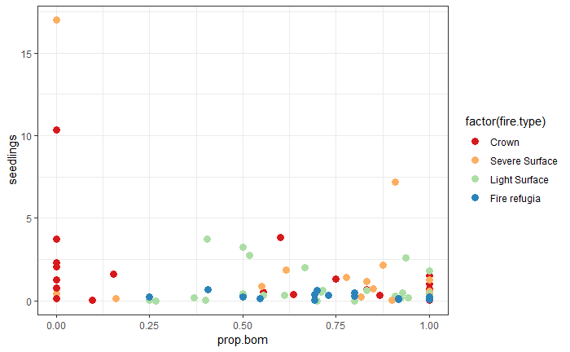

```r
ggplot(data = seedlings.plot, aes(x = prop.bom , y = seedling.per.area, color = factor(fire.type))) +
         geom_point(size = 3) +
         scale_color_manual(values=c("#d7191c", "#fdae61", "#abdda4", "#2b83ba")) +
          ylab("seedlings") +
          xlab("prop.bom")  +
          theme_bw()
```